# Practical Machine Learning Course Project

Mark Edosa

July 25, 2016

# Introduction

Using devices such as Jawbone Up, Nike FuelBand, and Fitbit it is now possible to collect a large amount of data about personal activity relatively inexpensively. These type of devices are part of the quantified self movement-a group of enthusiasts who take measurements about themselves regularly to improve their health, to find patterns in their behavior, or because they are tech geeks. One thing that people regularly do is quantify how much of a particular activity they do, but they rarely quantify how well they do it. In this project, your goal will be to use data from accelerometers on the belt, forearm, arm, and dumbell of 6 participants. They were asked to perform barbell lifts correctly and incorrectly in 5 different ways. More information is available from the website here: http://groupware.les.inf.puc-rio.br/har (see the section on the Weight Lifting Exercise Dataset).

Data Sources The training data for this project are available here: https://d396qusza40orc.cloudfront.net/predmachlearn/pml-training.csv The test data are available here: https://d396qusza40orc.cloudfront.net/predmachlearn/pml-testing.csv

Downloading the data and loading into R

```r
if (!file.exists("pml-training.csv")) {
        download.file("http://d396qusza40orc.cloudfront.net/predmachlearn/pml-training.csv", destfile = "pml-training.csv")
}
if (!file.exists("pml-testing.csv")) {
        download.file("http://d396qusza40orc.cloudfront.net/predmachlearn/pml-testing.csv", destfile = "pml-testing.csv")

}

testing <- read.csv("pml-testing.csv", header= TRUE) # read into R
training <- read.csv("pml-training.csv", header= TRUE)
```

Data Partitioning

the training data is split into training and validation data while the testing data is of course the test sample or new data.

```r
set.seed(1)
library(caret)
Intrain <- createDataPartition(y=training$classe, p=0.7, list=FALSE)
trainingData <- training[Intrain,]
validation <- training[-Intrain,]
dim(trainingData); dim(validation)# view the dimensions
```

```
## [1] 13737   160
```

```
## [1] 5885  160
```

Cleaning the data

```r
Nzvals <- nearZeroVar(trainingData, saveMetrics=TRUE) # shows the near zero covariates

## creating a subset without NZV variables:

Nzvals <- names(trainingData) %in% c("new_window", "kurtosis_roll_belt", "kurtosis_picth_belt", "kurtosis_yaw_belt", "skewness_roll_belt", "skewness_roll_belt.1", "skewness_yaw_belt", "max_yaw_belt", "min_yaw_belt", "amplitude_yaw_belt", "avg_roll_arm", "stddev_roll_arm", "var_roll_arm", "avg_pitch_arm", "stddev_pitch_arm", "var_pitch_arm", "avg_yaw_arm","stddev_yaw_arm", "var_yaw_arm", "kurtosis_roll_arm", "kurtosis_picth_arm","kurtosis_yaw_arm", "skewness_roll_arm", "skewness_pitch_arm", "skewness_yaw_arm","max_roll_arm", "min_roll_arm", "min_pitch_arm", "amplitude_roll_arm", "amplitude_pitch_arm", "kurtosis_roll_dumbbell", "kurtosis_picth_dumbbell", "kurtosis_yaw_dumbbell", "skewness_roll_dumbbell", "skewness_pitch_dumbbell", "skewness_yaw_dumbbell", "max_yaw_dumbbell", "min_yaw_dumbbell", "amplitude_yaw_dumbbell", "kurtosis_roll_forearm", "kurtosis_picth_forearm", "kurtosis_yaw_forearm","skewness_roll_forearm", "skewness_pitch_forearm", "skewness_yaw_forearm", "max_roll_forearm","max_yaw_forearm", "min_roll_forearm", "min_yaw_forearm", "amplitude_roll_forearm","amplitude_yaw_forearm", "avg_roll_forearm", "stddev_roll_forearm", "var_roll_forearm", "avg_pitch_forearm", "stddev_pitch_forearm", "var_pitch_forearm", "avg_yaw_forearm","stddev_yaw_forearm", "var_yaw_forearm")

newtData <- trainingData[!Nzvals]
dim(newtData)
```

```
## [1] 13737   100
```

```r
newtData <- newtData[c(-1)] # romoving the ID
```

Cleaning Variables with too many NAs here variables that have more than a 40% of NA’s are removed

```r
subsetnoNa <- newtData #creating another subset to iterate in loop
for(i in 1:length(newtData)) { # entire columns
        if(sum(is.na(newtData[, i] ) ) /nrow(newtData) >= 0.4 ) { #if n?? NAs >       40% of total observations
        for(j in 1:length(subsetnoNa)) {
        if( length( grep(names(newtData[i]), names(subsetnoNa)[j]) ) ==1)  { #if the columns are the same:
         subsetnoNa <- subsetnoNa[ , -j] #Remove that column
        }
   }
 }
}

dim(subsetnoNa)
```

```
## [1] 13737    58
```

```r
newTData1 <- subsetnoNa # refined training data
```

clean the validation and testing data sets as done above.

```r
clean1 <- colnames(newTData1)
clean2 <- colnames(newTData1[, -58]) #already with classe column removed
validData <- validation[clean1]
testing1 <- testing[clean2] # i changed the testing to testing cause a noticed # errors when i try to subset with same name or variable.
dim(validData) ; dim(testing1)
```

```
## [1] 5885   58
```

```
## [1] 20 57
```

coerce the data into the same type.

```r
 for (i in 1:length(testing1) ) {
          for(j in 1:length(newTData1)) {
          if( length( grep(names(newTData1[i]), names(testing1)[j]) ) ==1)  {
          class(testing1[j]) <- class(newTData1[i])
       }
}
}
testing1 <- rbind(newTData1[2, -58] , testing1)
testing1 <- testing1[-1,]
```

Training and predicting

# 1. Decision Tree

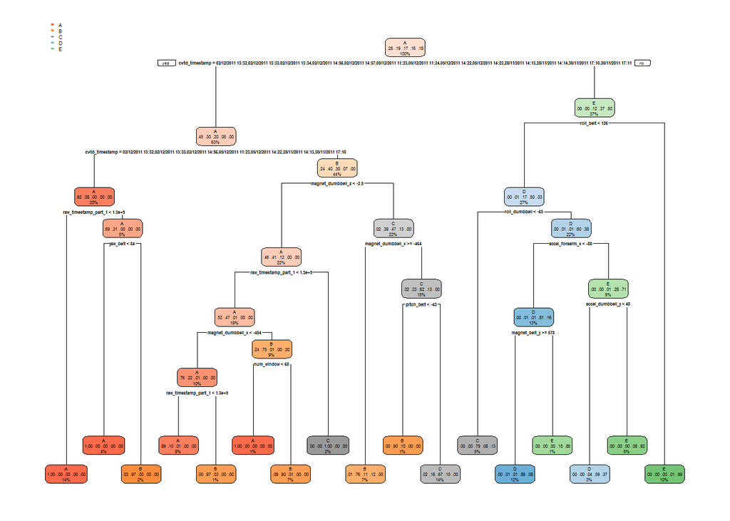

```r
library(rpart)
library(rpart.plot)
modFit1 <- rpart(classe ~ ., data=newTData1, method = "class") # produces an rpart object, which can be used to predict new data/test values
rpart.plot(modFit1)
```

```r
# Prediction:
predT <- predict(modFit1, validData, type = "class")
confusionMatrix(predT, validData$classe)
```

```
## Confusion Matrix and Statistics
##
##           Reference
## Prediction    A    B    C    D    E
##          A 1624   47    3    1    0
##          B   35  957   65   46    0
##          C   15  132  941  164   42
##          D    0    3   17  715  130
##          E    0    0    0   38  910
##
## Overall Statistics
##
##                Accuracy : 0.8746
##                  95% CI : (0.8659, 0.883)
##     No Information Rate : 0.2845
##     P-Value [Acc > NIR] : < 2.2e-16
##
##                   Kappa : 0.8414
##  Mcnemar's Test P-Value : NA
##
## Statistics by Class:
##
##                      Class: A Class: B Class: C Class: D Class: E
## Sensitivity            0.9701   0.8402   0.9172   0.7417   0.8410
## Specificity            0.9879   0.9692   0.9274   0.9695   0.9921
## Pos Pred Value         0.9696   0.8676   0.7272   0.8266   0.9599
## Neg Pred Value         0.9881   0.9619   0.9815   0.9504   0.9652
## Prevalence             0.2845   0.1935   0.1743   0.1638   0.1839
## Detection Rate         0.2760   0.1626   0.1599   0.1215   0.1546
## Detection Prevalence   0.2846   0.1874   0.2199   0.1470   0.1611
## Balanced Accuracy      0.9790   0.9047   0.9223   0.8556   0.9166
```

# 2. Random Forests

```r
library(randomForest)
modfitrf = randomForest(classe ~ ., newTData1)
# Predicting in-sample error:
predRF <- predict(modfitrf, validData, type = "class")
confusionMatrix(predRF, validData$classe)
```

```
## Confusion Matrix and Statistics
##
##           Reference
## Prediction    A    B    C    D    E
##          A 1674    1    0    0    0
##          B    0 1138    2    0    0
##          C    0    0 1024    2    0
##          D    0    0    0  962    1
##          E    0    0    0    0 1081
##
## Overall Statistics
##
##                Accuracy : 0.999
##                  95% CI : (0.9978, 0.9996)
##     No Information Rate : 0.2845
##     P-Value [Acc > NIR] : < 2.2e-16
##
##                   Kappa : 0.9987
##  Mcnemar's Test P-Value : NA
##
## Statistics by Class:
##
##                      Class: A Class: B Class: C Class: D Class: E
## Sensitivity            1.0000   0.9991   0.9981   0.9979   0.9991
## Specificity            0.9998   0.9996   0.9996   0.9998   1.0000
## Pos Pred Value         0.9994   0.9982   0.9981   0.9990   1.0000
## Neg Pred Value         1.0000   0.9998   0.9996   0.9996   0.9998
## Prevalence             0.2845   0.1935   0.1743   0.1638   0.1839
## Detection Rate         0.2845   0.1934   0.1740   0.1635   0.1837
## Detection Prevalence   0.2846   0.1937   0.1743   0.1636   0.1837
## Balanced Accuracy      0.9999   0.9994   0.9988   0.9989   0.9995
```

Random Forests yielded better Results.

# Answers for the Assignment

```r
# For Random Forests we use the following formula, which yielded a much better prediction in in-sample:
prediction2 <- predict(modfitrf, testing1, type = "class")
print(as.data.frame(prediction2))
```

```
##    prediction2
## 1            B
## 2            A
## 31           B
## 4            A
## 5            A
## 6            E
## 7            D
## 8            B
## 9            A
## 10           A
## 11           B
## 12           C
## 13           B
## 14           A
## 15           E
## 16           E
## 17           A
## 18           B
## 19           B
## 20           B
```